# Report Writing for Data Science in R Project 1

Zexia Hao  
September 5th 2016

## Data

The data for this assignment can be downloaded from the course web site:

- Dataset: [Activity monitoring data](https://d396qusza40orc.cloudfront.net/repdata%2Fdata%2Factivity.zip) [52K]

The variables included in this dataset are:

- **steps**: Number of steps taking in a 5-minute interval (missing values are coded as `NA`)
- **date**: The date on which the measurement was taken in YYYY-MM-DD format
- **interval**: Identifier for the 5-minute interval in which measurement was taken

The dataset is stored in a comma-separated-value (CSV) file and there are a total of 17,568 observations in this dataset.

## Loading and preprocessing the data

### 1. Load the data

```r
data<- read.csv("activity.csv")
```

### 2. Transform the data into a format suitable using dplyr

```r
library(dplyr)
data<-tbl_df(data)
data
```

```
## # A tibble: 17,568 x 3
##    steps       date interval
##    <int>     <fctr>    <int>
## 1     NA 2012-10-01        0
## 2     NA 2012-10-01        5
## 3     NA 2012-10-01       10
## 4     NA 2012-10-01       15
## 5     NA 2012-10-01       20
## 6     NA 2012-10-01       25
## 7     NA 2012-10-01       30
## 8     NA 2012-10-01       35
## 9     NA 2012-10-01       40
## 10    NA 2012-10-01       45
## # ... with 17,558 more rows
```

## What is the mean total number of steps taken per day?

### 1.Calculate the total number of stpes taken per day without missing values

```r
#group data with date
by_date<-group_by(data,date)
by_date
```

```
## Source: local data frame [17,568 x 3]
## Groups: date [61]
##
##    steps       date interval
##    <int>     <fctr>    <int>
## 1     NA 2012-10-01        0
## 2     NA 2012-10-01        5
## 3     NA 2012-10-01       10
## 4     NA 2012-10-01       15
## 5     NA 2012-10-01       20
## 6     NA 2012-10-01       25
## 7     NA 2012-10-01       30
## 8     NA 2012-10-01       35
## 9     NA 2012-10-01       40
## 10    NA 2012-10-01       45
## # ... with 17,558 more rows
```

```r
#calculate the total number,mean and medium of steps taken per day
stepsByDay<- summarize(by_date, total=sum(steps))
stepsByDay
```

```
## # A tibble: 61 x 2
##          date total
##        <fctr> <int>
## 1  2012-10-01    NA
## 2  2012-10-02   126
## 3  2012-10-03 11352
## 4  2012-10-04 12116
## 5  2012-10-05 13294
## 6  2012-10-06 15420
## 7  2012-10-07 11015
## 8  2012-10-08    NA
## 9  2012-10-09 12811
## 10 2012-10-10  9900
## # ... with 51 more rows
```

### 2.Calculate and report the mean and median of the total number of steps taken per day without missing values

```r
meanTotalStepsByDay<- mean(stepsByDay$total,na.rm=TRUE)
meanTotalStepsByDay
```

```
## [1] 10766.19
```

```r
medianTotalStepsByDay<- median(stepsByDay$total,na.rm = TRUE)
medianTotalStepsByDay
```

```
## [1] 10765
```

### 3.Make a histogram of the total number of steps taken per day

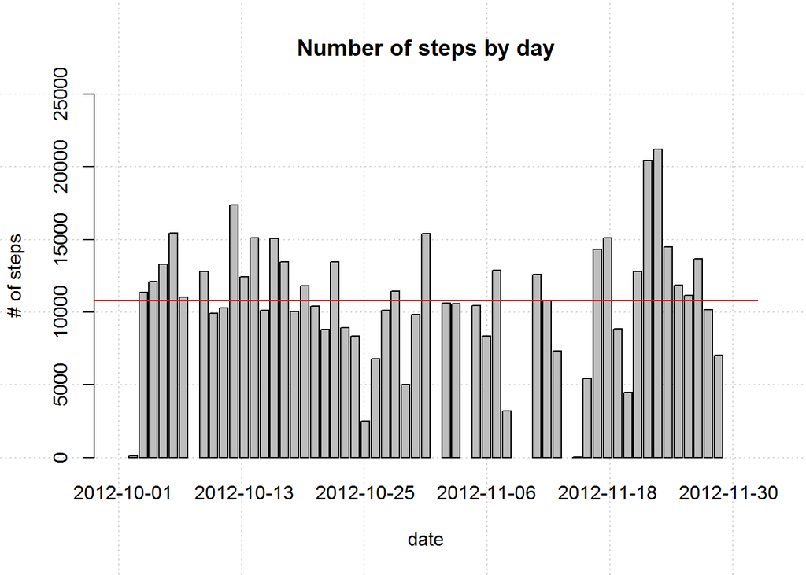

```r
with(stepsByDay, {
  barplot(height=stepsByDay$total, names.arg=date, xlab="date", ylim=c(0,25000),
          ylab="# of steps", main = "Number of steps by day", panel.first=grid())
})
abline(h=meanTotalStepsByDay, col="blue")
abline(h=medianTotalStepsByDay, col="red")
```

## What is the average daily activity partern?

### 1. Time series plot

```r
#construct a time series of the average number of steps taken per day and measured at each 5-minute interval
by_interval<-group_by(data,interval)
stepsByInterval<- summarize(by_interval,mean=mean(steps,na.rm=TRUE),total=sum(steps,na.rm = TRUE))
stepsByInterval
```

```
## # A tibble: 288 x 3
##    interval      mean total
##       <int>     <dbl> <int>
## 1         0 1.7169811    91
## 2         5 0.3396226    18
## 3        10 0.1320755     7
## 4        15 0.1509434     8
## 5        20 0.0754717     4
## 6        25 2.0943396   111
## 7        30 0.5283019    28
## 8        35 0.8679245    46
## 9        40 0.0000000     0
## 10       45 1.4716981    78
## # ... with 278 more rows
```

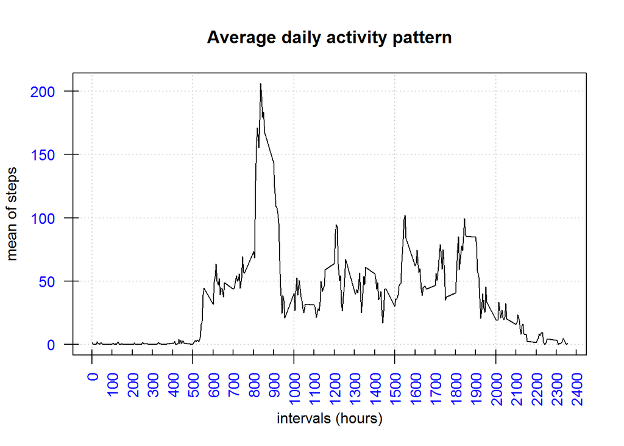

```r
# make time series plot
with(stepsByInterval, {
  plot(stepsByInterval$interval, stepsByInterval$mean, type="l", xlab="intervals (hours)", ylab="mean of steps",
       main="Average daily activity pattern", panel.first=grid(),
       col.axis="white")

  # Add minor tick marks
  xMarks <- seq(from = 0, to = 2400, by = 100)
  yMarks <- seq(from = 0, to = 200, by = 50)
  axis(1, at=xMarks, col.axis="blue", las=2, tck=0.02)
  axis(2, at=yMarks, col.axis="blue", las=2, tck=0.02)

})
```

### 2.Which 5-minute interval, on average across all the days in the dataset, contains the maximum number of steps?

```r
# maximum number of steps
maxSteps <- stepsByInterval$interval[which.max(stepsByInterval$total)]
maxSteps
```

```
## [1] 835
```

## Imputing missing values

### 1.Calculate the total number of missing values in the dataset

```r
#calculate the total number of missing values
totMissing <- sum(is.na(data))
totMissing
```

```
## [1] 2304
```

### 2.A strategy for filling in all of the missing values in the dataset could use the mean for that 5-min interval. And that’s what we do:

```r
data$steps_2 <- data$steps   # create a new column of steps derivated from 1st one
nObs <- nrow(data)
iRow <- 1
while(iRow <= nObs) {
  if( is.na(data$steps[iRow]) ) {
    intervalRow <- data$interval[iRow]
    data$steps_2[iRow] = stepsByInterval$mean[which(stepsByInterval$interval==intervalRow)]
  }
  iRow <- iRow+1
}
```

### 3.the new mean and medium of total number of stpes taken per day with missing values

```r
by_date2<-group_by(data,date)
stepsByDay2<- summarize(by_date2, total=sum(steps_2))
stepsByDay2
```

```
## # A tibble: 61 x 2
##          date    total
##        <fctr>    <dbl>
## 1  2012-10-01 10766.19
## 2  2012-10-02   126.00
## 3  2012-10-03 11352.00
## 4  2012-10-04 12116.00
## 5  2012-10-05 13294.00
## 6  2012-10-06 15420.00
## 7  2012-10-07 11015.00
## 8  2012-10-08 10766.19
## 9  2012-10-09 12811.00
## 10 2012-10-10  9900.00
## # ... with 51 more rows
```

```r
# new mean
meanTotalStepsByDay2<- mean(stepsByDay2$total)
meanTotalStepsByDay2
```

```
## [1] 10766.19
```

```r
# new median
medianTotalStepsByDay2<- median(stepsByDay2$total)
medianTotalStepsByDay2
```

```
## [1] 10766.19
```

### 4.Making a histogram of the total number of steps taken each day and calculating and reporting the mean and median total number of steps taken per day.

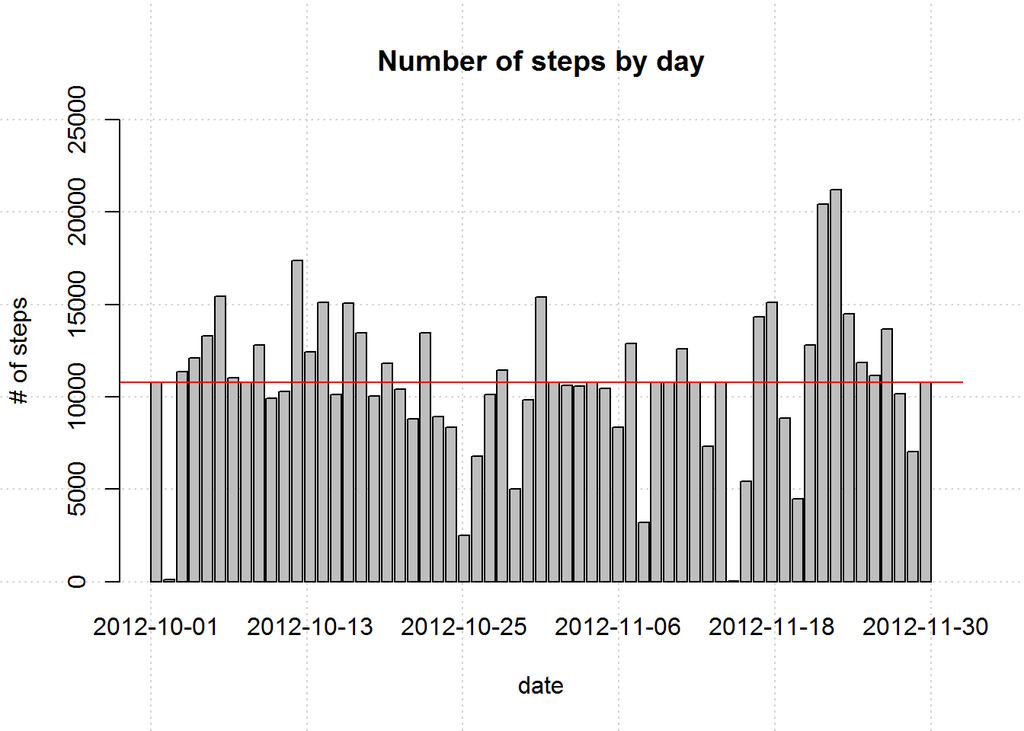

```r
with(stepsByDay2, {
      barplot(height=stepsByDay2$total, names.arg=date, xlab="date", ylim=c(0,25000),
          ylab="# of steps", main = "Number of steps by day", panel.first=grid())
})
abline(h=meanTotalStepsByDay2, col="blue")
abline(h=medianTotalStepsByDay2, col="red")
```

## Are there difference in activity partterns bewteen weekdays and weekends?

### 1.Create a new factor variable in the dataset with two levels – “weekday” and “weekend” indicating whether a given date is a weekday or weekend day.

```r
#distinguish the weekday and weekend using build a week_period function
typeDay<-c("weekend","weekday")
week_period <- function(v_date) {
  i <- as.POSIXlt(as.Date(v_date))$wday
  return( ifelse(i == 0 || i == 6, typeDay[1], typeDay[2]) )
}
# add new variable for data to sign the day type
data$typeDay <- as.factor( sapply(data$date, week_period) )
```

### 2.Make a panel plot containing a time series plot of the 5-minute interval (x-axis) and the average number of steps taken, averaged across all weekday days or weekend days (y-axis).

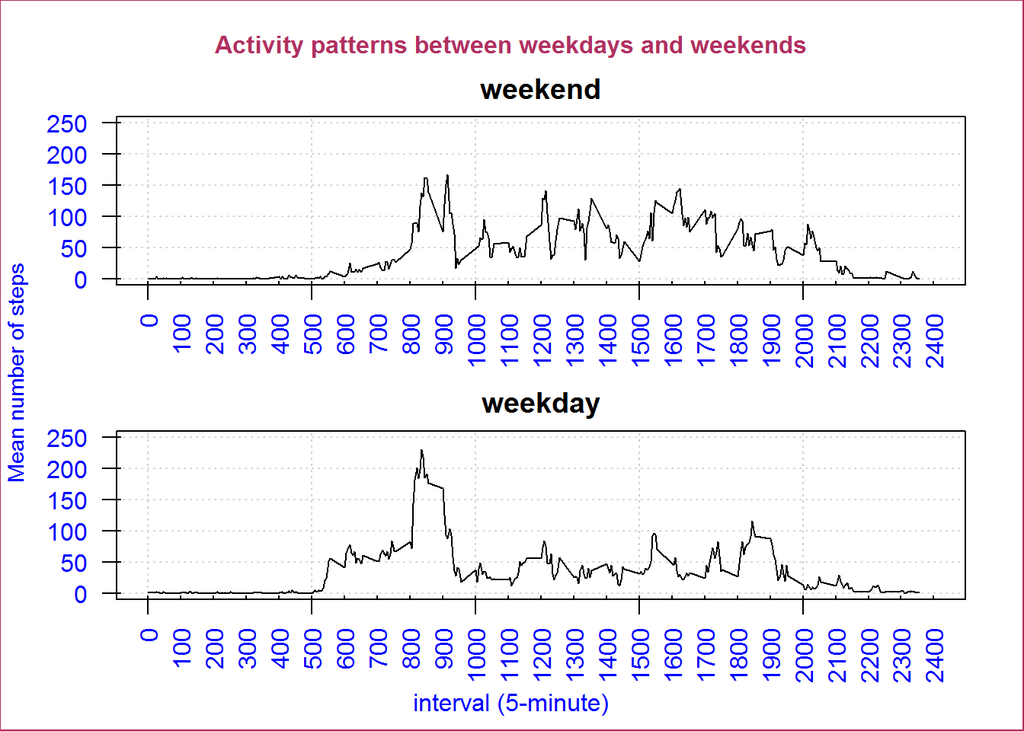

```r
par(mfrow=c(2, 1), mar=c(3, 3, 2, 1), oma=c(1.5, 1, 2, 1))

# make a diagram
for(i in typeDay ){
  stepsByTpDay <- aggregate(steps_2 ~ interval, data = data, subset = (data$typeDay == i), FUN = mean)
  plot(stepsByTpDay, type = "l", main = i, xlab="", ylab="", ylim=c(0,250), xlim=c(0,2400),
       panel.first=grid(), col.axis='white')

  xMarks <- seq(from = 0, to = 2400, by = 100)
  axis(1, at=xMarks, col.axis="blue", las=2, tck=0.02)
  yMarks <- seq(from = 0, to = 250, by = 50)
  axis(2, at=yMarks, col.axis="blue", las=2, tck=0.02)
}

mtext( "interval (5-minute)", side=1, outer=TRUE, col="blue", font=1 )
mtext( "Mean number of steps", side=2, outer=TRUE, col="blue", font=1, cex=0.9 )
mtext( "Activity patterns between weekdays and weekends", side=3, outer=TRUE, col="maroon", font=2 )
box("outer", col="maroon")
```